# And the Oscar Goes To…. A Sneak Peak at the Most Awarded Films in The Academy

Tuba Siddiqui

2025-05-06

```r
library(tidyverse)
library(readr)
library(caret) #package for training, tuning, and evaluating machine learning models
library(rpart) #package for creating classification and regression trees
library(pROC)
library(rpart.plot) #package for plotting classification and regression trees
```

# Introduction

I will explore how many nominations winning films typically receive, how many translate into wins, and whether we can predict whether a film will get multiple nominations based on its category and year.

Dataset: [Academy Awards, 1927-2025 - Kaggle](https://www.kaggle.com/datasets/unanimad/the-oscar-award)

I will evaluate the model’s performance using ROC curves and accuracy metrics.

```r
#load our data
oscars <- read_delim("the_oscar_award.csv", delim = ",")
full_data <- read_delim("full_data.csv", delim = "\t")
#let's take a peek at the first few rows
head(oscars)
```

```
## # A tibble: 6 × 8
##   year_film year_ceremony ceremony category canon_category    name  film  winner
##       <dbl>         <dbl>    <dbl> <chr>    <chr>             <chr> <chr> <lgl>
## 1      1927          1928        1 ACTOR    ACTOR IN A LEADI… Rich… The … FALSE
## 2      1927          1928        1 ACTOR    ACTOR IN A LEADI… Rich… The … FALSE
## 3      1927          1928        1 ACTOR    ACTOR IN A LEADI… Emil… The … TRUE
## 4      1927          1928        1 ACTOR    ACTOR IN A LEADI… Emil… The … TRUE
## 5      1927          1928        1 ACTRESS  ACTRESS IN A LEA… Loui… A Sh… FALSE
## 6      1927          1928        1 ACTRESS  ACTRESS IN A LEA… Jane… 7th … TRUE
```

```r
head(full_data)
```

```
## # A tibble: 6 × 16
##   Ceremony Year    Class  CanonicalCategory    Category NomId Film  FilmId Name
##      <dbl> <chr>   <chr>  <chr>                <chr>    <chr> <chr> <chr>  <chr>
## 1        1 1927/28 Acting ACTOR IN A LEADING … ACTOR    an00… The … tt001… Rich…
## 2        1 1927/28 Acting ACTOR IN A LEADING … ACTOR    an00… The … tt001… Rich…
## 3        1 1927/28 Acting ACTOR IN A LEADING … ACTOR    an00… The … tt001… Emil…
## 4        1 1927/28 Acting ACTOR IN A LEADING … ACTOR    an00… The … tt001… Emil…
## 5        1 1927/28 Acting ACTRESS IN A LEADIN… ACTRESS  an00… A Sh… tt001… Loui…
## 6        1 1927/28 Acting ACTRESS IN A LEADIN… ACTRESS  an00… 7th … tt001… Jane…
## # ℹ 7 more variables: Nominees <chr>, NomineeIds <chr>, Winner <lgl>,
## #   Detail <chr>, Note <chr>, Citation <chr>, MultifilmNomination <lgl>
```

```r
#view the structure
glimpse(oscars)
```

```
## Rows: 11,110
## Columns: 8
## $ year_film      <dbl> 1927, 1927, 1927, 1927, 1927, 1927, 1927, 1927, 1927, 1…
## $ year_ceremony  <dbl> 1928, 1928, 1928, 1928, 1928, 1928, 1928, 1928, 1928, 1…
## $ ceremony       <dbl> 1, 1, 1, 1, 1, 1, 1, 1, 1, 1, 1, 1, 1, 1, 1, 1, 1, 1, 1…
## $ category       <chr> "ACTOR", "ACTOR", "ACTOR", "ACTOR", "ACTRESS", "ACTRESS…
## $ canon_category <chr> "ACTOR IN A LEADING ROLE", "ACTOR IN A LEADING ROLE", "…
## $ name           <chr> "Richard Barthelmess", "Richard Barthelmess", "Emil Jan…
## $ film           <chr> "The Noose", "The Patent Leather Kid", "The Last Comman…
## $ winner         <lgl> FALSE, FALSE, TRUE, TRUE, FALSE, TRUE, TRUE, TRUE, FALS…
```

```r
glimpse(full_data)
```

```
## Rows: 12,014
## Columns: 16
## $ Ceremony            <dbl> 1, 1, 1, 1, 1, 1, 1, 1, 1, 1, 1, 1, 1, 1, 1, 1, 1,…
## $ Year                <chr> "1927/28", "1927/28", "1927/28", "1927/28", "1927/…
## $ Class               <chr> "Acting", "Acting", "Acting", "Acting", "Acting", …
## $ CanonicalCategory   <chr> "ACTOR IN A LEADING ROLE", "ACTOR IN A LEADING ROL…
## $ Category            <chr> "ACTOR", "ACTOR", "ACTOR", "ACTOR", "ACTRESS", "AC…
## $ NomId               <chr> "an0051251", "an0051252", "an0051250a", "an0051250…
## $ Film                <chr> "The Noose", "The Patent Leather Kid", "The Last C…
## $ FilmId              <chr> "tt0019217", "tt0018253", "tt0019071", "tt0019553"…
## $ Name                <chr> "Richard Barthelmess", "Richard Barthelmess", "Emi…
## $ Nominees            <chr> "Richard Barthelmess", "Richard Barthelmess", "Emi…
## $ NomineeIds          <chr> "nm0001932", "nm0001932", "nm0417837", "nm0417837"…
## $ Winner              <lgl> NA, NA, TRUE, TRUE, NA, TRUE, TRUE, TRUE, NA, NA, …
## $ Detail              <chr> "Nickie Elkins", "The Patent Leather Kid", "Genera…
## $ Note                <chr> NA, NA, NA, NA, NA, NA, NA, NA, NA, NA, NA, NA, NA…
## $ Citation            <chr> NA, NA, NA, NA, NA, NA, NA, NA, NA, NA, NA, NA, NA…
## $ MultifilmNomination <lgl> TRUE, TRUE, TRUE, TRUE, NA, TRUE, TRUE, TRUE, NA, …
```

```r
#look at column names
colnames(oscars)
```

```
## [1] "year_film"      "year_ceremony"  "ceremony"       "category"
## [5] "canon_category" "name"           "film"           "winner"
```

```r
#look at column names
colnames(full_data)
```

```
##  [1] "Ceremony"            "Year"                "Class"
##  [4] "CanonicalCategory"   "Category"            "NomId"
##  [7] "Film"                "FilmId"              "Name"
## [10] "Nominees"            "NomineeIds"          "Winner"
## [13] "Detail"              "Note"                "Citation"
## [16] "MultifilmNomination"
```

## Loading and Preparing the Data

```r
#filtering out our dataset to only include the colmns we need
film_data <- full_data |>
  select(Ceremony, Year, Category, Film, Winner, Nominees) |>
  filter(!is.na(Category), !is.na(Ceremony), !is.na(Year), !is.na(Winner), !is.na(Nominees), !is.na(Film))

#count nominations & wins by film
film_nominations <- film_data |>
  group_by(Film) |>
  summarise(total_nominations = n())

film_wins <- film_data |>
  filter(Winner == TRUE) |>
  group_by(Film) |>
  summarise(total_wins = n())

#to combine nominations and wins to calculate win rate
film_data <- film_data |>
  group_by(Film) |>
  mutate(total_nominations = n(),
         high_noms = ifelse(total_nominations >= 5, "Yes", "No")) |>
  ungroup()

#to convert high_noms to facttor
film_data$high_noms <- factor(film_data$high_noms)
table(film_data$high_noms)
```

```
##
##   No  Yes
## 1703  460
```

**Nominations & Wins**

```r
#to count nominations & wins
film_nominations <- film_data |>
  group_by(Film) |>
  summarise(total_nominations = n())

film_wins <- film_data |>
  filter(Winner == TRUE) |>
  group_by(Film) |>
  summarise(total_wins = n())

film_summary <- film_nominations |>
  left_join(film_wins, by = "Film") |>
  mutate(total_wins = replace_na(total_wins, 0), win_rate = total_wins / total_nominations)

#to take a quick look at our data
head(film_summary)
```

```
## # A tibble: 6 × 4
##   Film                         total_nominations total_wins win_rate
##   <chr>                                    <int>      <int>    <dbl>
## 1 'Round Midnight                              1          1        1
## 2 12 Years a Slave                             3          3        1
## 3 1917                                         3          3        1
## 4 20 Days in Mariupol                          1          1        1
## 5 20 Feet from Stardom                         1          1        1
## 6 20,000 Leagues under the Sea                 2          2        1
```

**Top 10 Nominated Films**

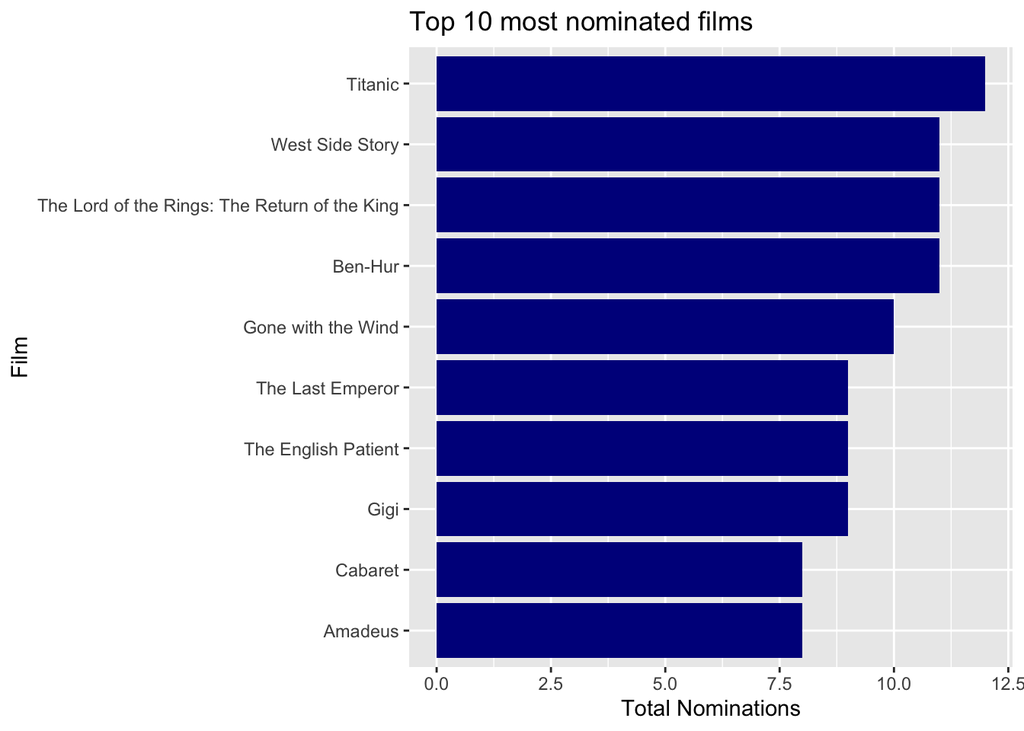

```r
top_films <- film_summary |>
  arrange(desc(total_nominations)) |>
  slice(1:10)

#ggplot to visualize the top 10 films
ggplot(top_films, aes(x = reorder(Film, total_nominations), y = total_nominations)) +
  geom_bar(stat = "identity", fill = "darkblue") +
  coord_flip() +
  labs(title = "Top 10 most nominated films",
       x = "Film",
       y = "Total Nominations")
```

```r
  theme_minimal()
```

[output not shown]

[output cut: 240 more lines]

[output not shown]

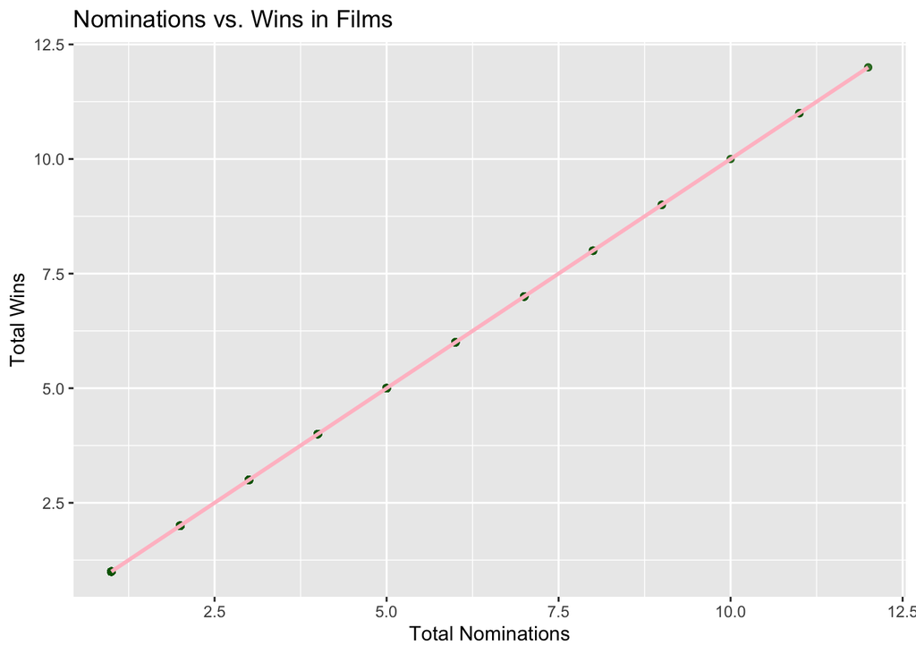

```r
#ggplot to visualise nomination vs wins
ggplot(film_summary, aes(x = total_nominations, y = total_wins)) +
  geom_point(alpha = 0.8, color = "darkgreen") +
  geom_smooth(method = "lm", se = FALSE, color = "pink") +
  labs(title = "Nominations vs. Wins in Films",
       x = "Total Nominations",
       y = "Total Wins")
```

```r
  theme_minimal()
```

[output not shown]

[output cut: 240 more lines]

[output not shown]

**Model Training**

```r
#to convert to factor
film_data$high_noms <- factor(film_data$high_noms)
table(film_data$high_noms)
```

```
##
##   No  Yes
## 1703  460
```

```r
#to add broader category_group to simplify categories
film_data <- film_data |>
  mutate(category_group = case_when(
    str_detect(Category, "PICTURE|PRODUCTION") ~ "Picture/Production",
    str_detect(Category, "ACTOR|ACTRESS|ACTING") ~ "Acting",
    str_detect(Category, "DIRECTING") ~ "Directing",
    str_detect(Category, "WRITING") ~ "Writing",
    str_detect(Category, "MUSIC|SOUND") ~ "Music/Sound",
    str_detect(Category, "EDITING") ~ "Editing",
    TRUE ~ "Other"
  ))

#to check the new groups
table(film_data$category_group)
```

```
##
##             Acting          Directing            Editing        Music/Sound
##                377                 98                 91                365
##              Other Picture/Production            Writing
##                913                111                208
```

**Classification Tree**

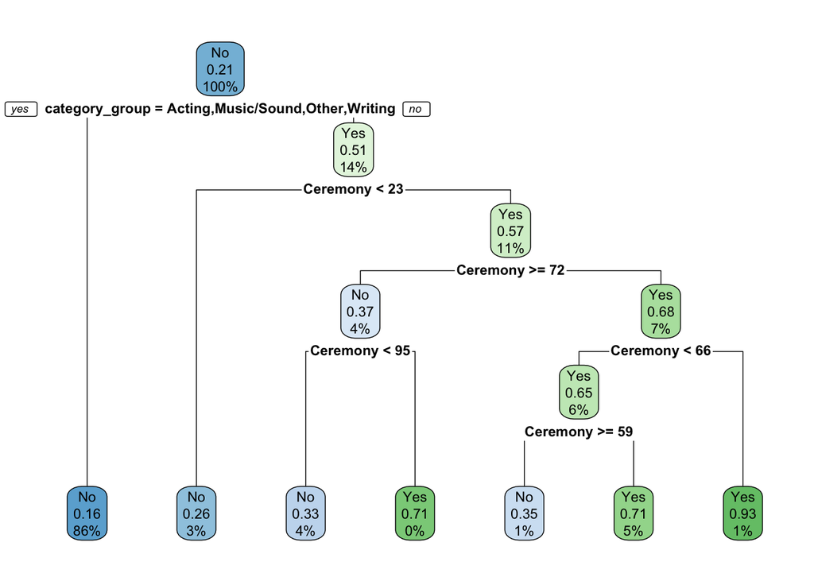

```r
#to ensure reproducibility
set.seed(248402)
#we have to split our training data by 75% & our testing data by 25%
train_index <- createDataPartition(film_data$high_noms, p = 0.75, list = FALSE)
train_data <- film_data[train_index, ]
test_data <- film_data[-train_index, ]

# Train the tree
tree_oscars <- rpart(
  high_noms ~ category_group + Ceremony,
  data = train_data,
  method = "class",
  control = rpart.control(cp = 0.005, minsplit = 10)
)

#to plot
rpart.plot(tree_oscars)
```

**Decision Tree Summary**

Our classification tree model predicts whether a film receives high nominations which is 5 or more nominations based on the Ceremony Year and Category of the Oscar award.

**Prediction**

```r
#to make predictions on the test data
pred_oscars <- predict(tree_oscars, newdata = test_data, type = "prob")[,2]

#to convert probab to binary outcomes
pred_binary <- ifelse(pred_oscars > 0.5, 1, 0)

#to ensure the correct binary outcome for comparison in the test data
oscars_binary <- ifelse(test_data$high_noms == "Yes", 1, 0)

#to compare predicted values with actual values
accuracy <- mean(pred_binary == oscars_binary)
accuracy
```

```
## [1] 0.812963
```

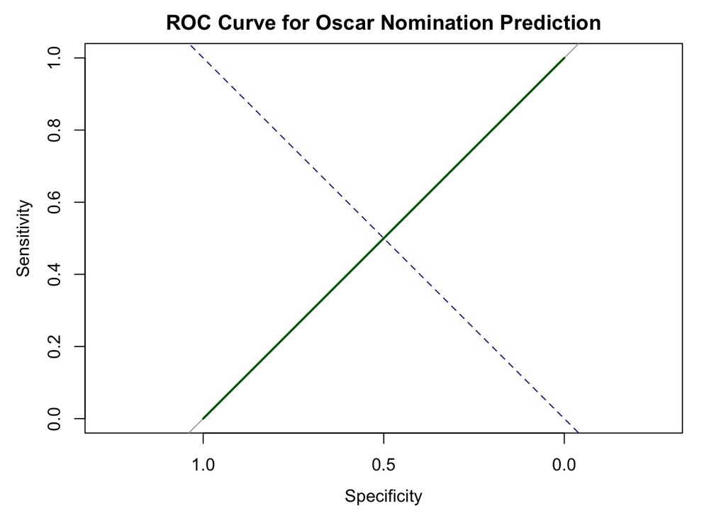

```r
#to make sure category_group levels match in test data
test_data$category_group <- factor(test_data$category_group, levels = levels(train_data$category_group))

#to get predicted prob for Yes
pred_probs <- predict(tree_oscars, newdata = test_data, type = "prob")[,2]  # Probabilities of "Yes"

#lets create binary acutal outcomws
oscars_actuals <- ifelse(test_data$high_noms == "Yes", 1, 0)

#ROC Curve & AUC
roc_curve <- roc(oscars_actuals, pred_probs)
auc_value <- auc(roc_curve)

#to plot ROC curve
plot(roc_curve, col = "darkgreen", main = "ROC Curve for Oscar Nomination Prediction")
abline(a = 0, b = 1, lty = 2, col = "darkblue")
```

```r
#lets print AUC value
auc_value
```

```
## Area under the curve: 0.5
```

## Conclusion

In this project, I explored Oscar nomination and win patterns from 1927 to 2025. I built a decision tree to predict if a film would get 5 or more nominations based on its award category and the year.

Throughout the process, I got to learn that our tree provides some useful insights into how categories and ceremony years relate to nomination patterns. Our model’s accuracy showed it could make reasonable predictions on the test data. However, the ROC curve and AUC showed that the model didn’t perform much better than random guessing. This suggests us that other factors like box office performance & budget, film reviews, or film industry trends are important and were missing from this data.

For future work, adding more film related data and trying different models, like logistic regression, might improve our desired predictions.

## References

Dataset: [Academy Awards, 1927-2025 - Kaggle](https://www.kaggle.com/datasets/unanimad/the-oscar-award) R Packages: tidyverse, caret, rpart, pROC.